# Generación de números aleatorios con "dispositivos" físicos

Ejemplos

```
- Ruido físico.
- Sistemas caóticos físicos.
```

Aplicaciones de números aleatorios

```
- Protocolos de comunicación.
- Simulaciones Monte Carlo.
- Cómputo científico.
- Aplicaciones de juegos.
- Aplicaciones de entropía masiva como limpieza segura de disco o destrucción de documentos.
- Protección de servicios en línea contra ataques RNG.
- Iniciar secuencias de números pseudo alatorios.
```

Problemas / percances :

```
- Falata de replicabilidad.
- Sesgo sistemático difícil de cuantificar.
```

### Ejemplo

Podemos generar números aleatorios al considerara el decaimiento radioactivo de un isótopo. En particular consideramos el isótopo americium-241 que tiene aplicaciones comerciales en las cámaras de ionización dentro de los detectores de humo. El isótopo decae al emitir partículas alfa y tiene una vida media de 432.2 años.

```julia
data
```

|  | N Int64 | Freq Int64 |
| --- | --- | --- |
| 1 | 0 | 1 |
| 2 | 1 | 4 |
| 3 | 2 | 13 |
| 4 | 3 | 28 |
| 5 | 4 | 56 |
| 6 | 5 | 105 |
| 7 | 6 | 126 |
| 8 | 7 | 146 |
| 9 | 8 | 164 |
| 10 | 9 | 161 |
| 11 | 10 | 123 |
| 12 | 11 | 101 |
| 13 | 12 | 74 |
| 14 | 13 | 53 |
| 15 | 14 | 23 |
| 16 | 15 | 15 |
| 17 | 16 | 9 |
| 18 | 17 | 3 |
| 19 | 18 | 1 |
| 20 | 19 | 1 |

```julia
plot(p)
```

[figure not shown]

```julia
n_obs
```

```
1207
```

```julia
ChisqTest(O,E)
```

```
Pearson's Chi-square Test
-------------------------
Population details:
    parameter of interest:   Multinomial Probabilities
    value under h_0:         [0.002176950864259458, 0.008135029351917174, 0.022688666507873934, 0.047459163849009674, 0.07941840856854165, 0.11074931070611732, 0.13237747530134678, 0.13845071697061942, 0.1287134116437711, 0.10769484210359934, 0.08191686453297052, 0.057116709121683894, 0.036761305552…
    point estimate:          [0.004142502071251036, 0.010770505385252692, 0.0231980115990058, 0.0463960231980116, 0.08699254349627175, 0.1043910521955261, 0.12096106048053024, 0.13587406793703397, 0.13338856669428334, 0.10190555095277548, 0.08367854183927093, 0.061309030654515324, 0.0439105219552609…
    95% confidence interval: Tuple{Float64,Float64}[(0.0, 0.0289), (0.0, 0.0355), (0.0, 0.048), (0.0232, 0.0712), (0.0638, 0.1118), (0.0812, 0.1292), (0.0978, 0.1457), (0.1127, 0.1606), (0.1102, 0.1582), (0.0787, 0.1267), (0.0605, 0.1084), (0.0381, 0.0861), (0.0207, 0.0687), (0.0, 0.0438), (0.0, 0.0…

Test summary:
    outcome with 95% confidence: fail to reject h_0
    one-sided p-value:           0.8845

Details:
    Sample size:        1207
    statistic:          9.644040919065262
    degrees of freedom: 16
    residuals:          [1.463570625169746, 1.0151568374002717, 0.11747927946071723, -0.16954473908082865, 0.9337402552872908, -0.6637756250507904, -1.0901250734149541, -0.24058098443959797, 0.45272841451623347, -0.6128886438901137, 0.21384216096352593, 0.6094339308873805, 1.2954379477432765, -0.683…
    std. residuals:     [1.4651662915770964, 1.0193113679096175, 0.11883511933040639, -0.17371707837656347, 0.9731839534407047, -0.7038971310382344, -1.1703369573189575, -0.2591917864223047, 0.4850173097533071, -0.6488209623220562, 0.22317848729411266, 0.6276212804840507, 1.3199262156215472, -0.6908…
```

```julia
T = sum( ( O .- E*n_obs ).^2.0 ./ (E*n_obs) )
```

```
9.644040919065219
```

```julia
p₁ = ccdf( Chisq(16), T )
```

```
0.8845446181984359
```

```julia
p₂ = ccdf( Chisq(15), T )
```

```
0.8415134383474953
```

## Números Pseudoalateorios

Nos enfocaremos en números aleatorios Uniforme(0,1)

```
- Son la estructura básica de aleatoriedad.
- Nos permiten generar números aleatorios de cualquier otra distribución de probabilidad.
```

#### Definición

Un generador de números pseudo alatorios uniformes es una cuarteta $(E,f,g,\mathbb{P}_0)$ tal que $E$ es un conjunto de estados (en práctica finito), $f\, ; \, E\to E$, $g \, : \, E \to [0,1]$, $\mathbb{P}_0$ es una distribución de probabilidad asociada a la elección del estado incial $x_0$ y $\forall n > 0$, natural, se satisface que la secuencia $\left\{ y_i \right\}_{i=1}^n$ dada por

\begin{align*} y_n &= g(x_n), \\ x_n & = f(x_{n-1}); \quad n\geq 1. \end{align*}

reproducen el comportamiento de una muestra independiente identicamente distribuida Uniforme(0,1) cuando se las compara con una batería de pruebas estadísticas.

Denotamos tales algoritmos como PRNG's por sus siglas en inglés (pseudo random number generators).

Observaciones

```
- ("Filosófica") Tal vez no es posible reproducir aleatoriedad con secuencias determinísticas finitas.
- Los números pseudo aleatorios están restringidos a la prueba de hipoótesis
```

$$H_0 \, : \, y_1, \ldots ,y_n \stackrel{\text{i.i.d.}}{\sim}\text{Uniforme}(0,1)$$

```
- La validez de un generador de números pseudo alatorios se basa en una única muestra
```

$$\left\{ y_i \right\}_{i=1}^n.$$

```
- Dos secuencias producidas por el algoritmo PRNG
```

$$\left\{ y_i^{(1)} \right\}_{i=1}^n, \quad \left\{ y_i^{(2)} \right\}_{i=1}^n$$

```
no son independientes ni identicamente distribuidas, de hecho no hay una noción probabilística para poder compararlas.
```

### Generadores caóticos

Definimos el mapeo logístico como $f_r(x)=rx(1-x)$. Observaremos que para valores de $r\in [3.57,4.0]$ este mapeo tiene un comportamiento caótico con estructuras deterministas complejas que son altamente sensibles a la condición incial $x_0$.

```
┌ Info: Saved animation to
│   fn = /home/workstation/Documents/Simulacion/anim_nochaos.gif
└ @ Plots /home/workstation/.julia/packages/Plots/u8HRI/src/animation.jl:104
```

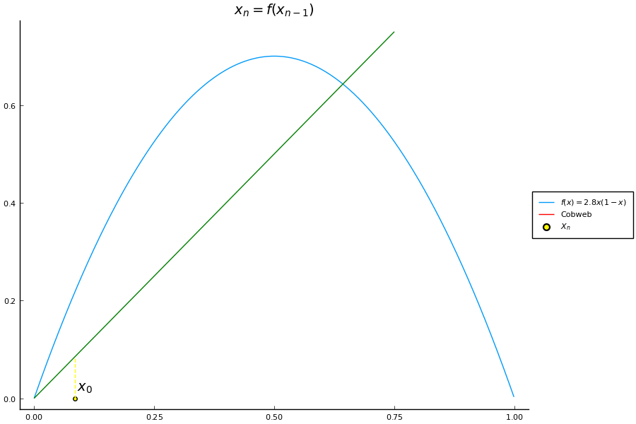

```julia
gif(anim, "anim_nochaos.gif", fps = 5)
```

```
┌ Info: Saved animation to
│   fn = /home/workstation/Documents/Simulacion/anim_nochaos_inic2.gif
└ @ Plots /home/workstation/.julia/packages/Plots/u8HRI/src/animation.jl:104
```

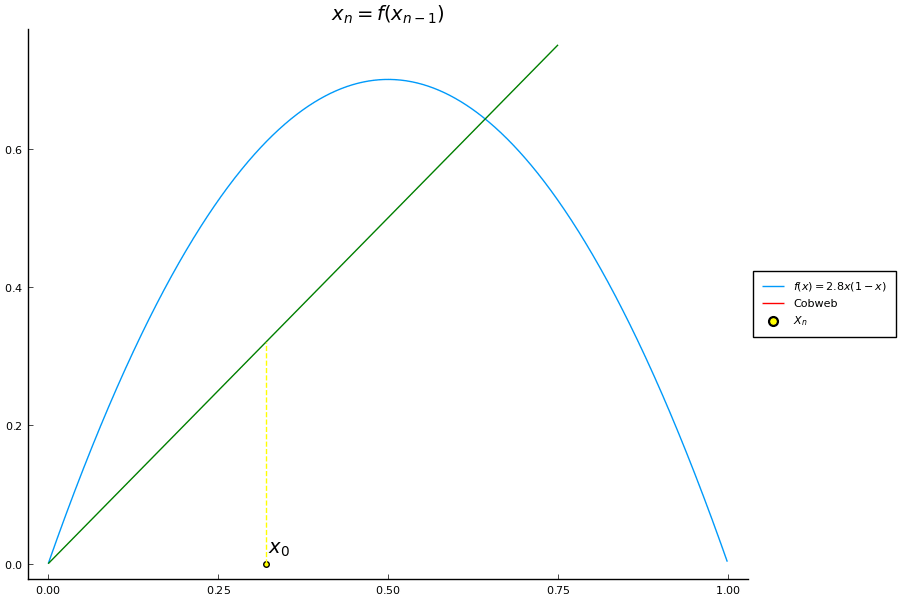

```julia
gif(anim, "anim_nochaos_inic2.gif", fps = 5)
```

```
┌ Info: Saved animation to
│   fn = /home/workstation/Documents/Simulacion/anim_chaos.gif
└ @ Plots /home/workstation/.julia/packages/Plots/u8HRI/src/animation.jl:104
```

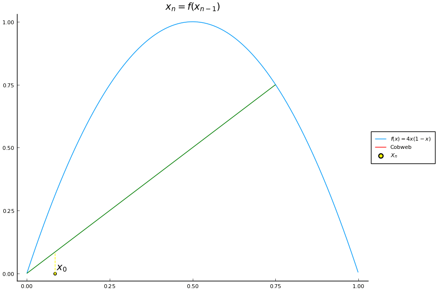

```julia
gif(anim, "anim_chaos.gif", fps = 15)
```

```
┌ Info: Saved animation to
│   fn = /home/workstation/Documents/Simulacion/anim_chaos_inic2.gif
└ @ Plots /home/workstation/.julia/packages/Plots/u8HRI/src/animation.jl:104
```

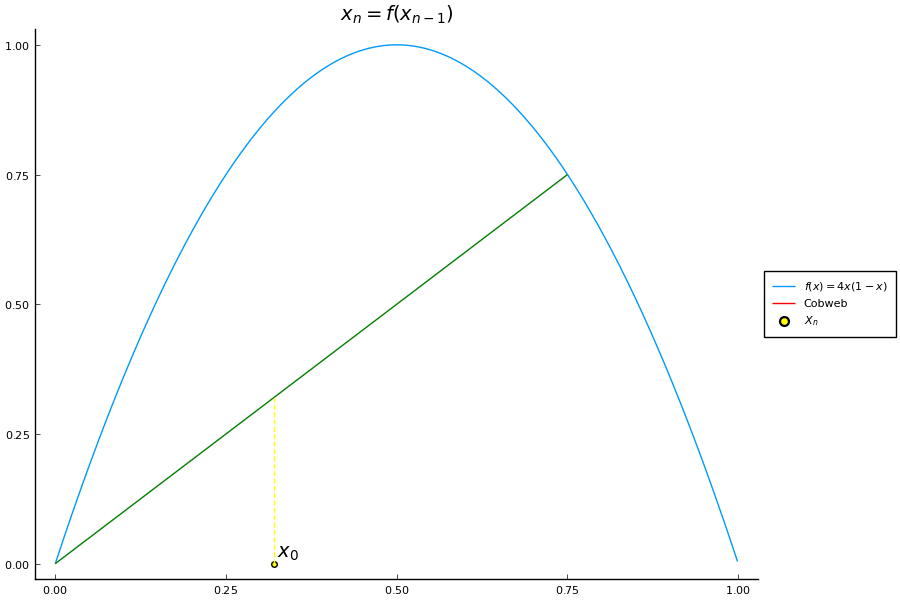

```julia
gif(anim, "anim_chaos_inic2.gif", fps = 15)
```

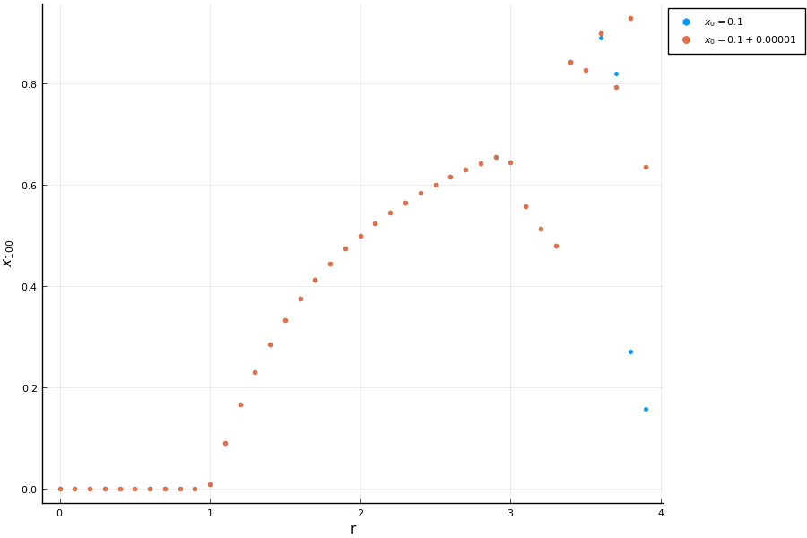

```julia
plot(p)
```

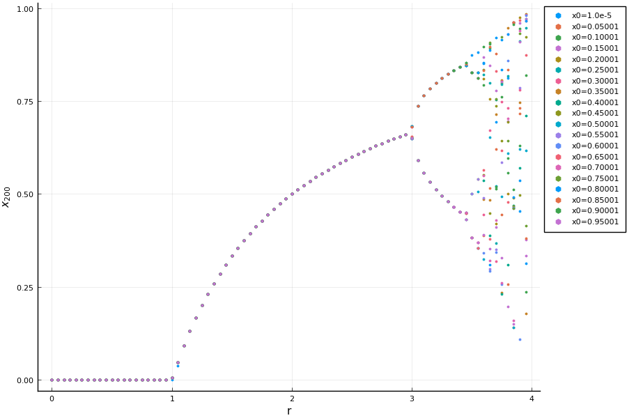

```julia
plot(p)
```

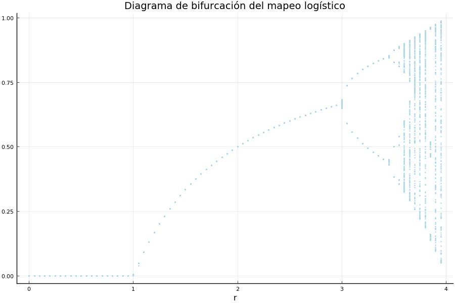

```julia
plot(p)
```

## Distribución invariante sobre mapeo determinista

Dado un mapeo $f\, : \, E \to E $, decimos que una distribución asociada a una variable aleatoria $X$ es invariante sobre el mapeo si

\begin{align*} \mathbb{P}\left[ X \leq x \right] = \mathbb{P}\left[ f( X ) \leq x \right], \quad x\in E. \end{align*}

La distribución invariante del mapeo logístico está dada por la siguiente ecuación funcional

\begin{align*} h(x) = \frac{1}{r\sqrt{1-\frac{4x}{r}}} \left( h\left( \frac{1}{2} \left( 1 - \sqrt{1 - \frac{4x}{r} } \right) \right) + h\left( \frac{1}{2} \left( 1 + \sqrt{1 - \frac{4x}{r} } \right) \right) \right) \end{align*}

donde $h$ es la función de densidad de probabilidad asociada a la distribución invariante.

La distribución invariante para el mapeo logístico sólo es conocida explícitamente para el caso $r=4$ en el cual la ecuación funcional anterior tiene solución dada por la densidad de una variable aleatoria $\text{Beta}\left( \, 1/2, \, 1/2 \right)$.

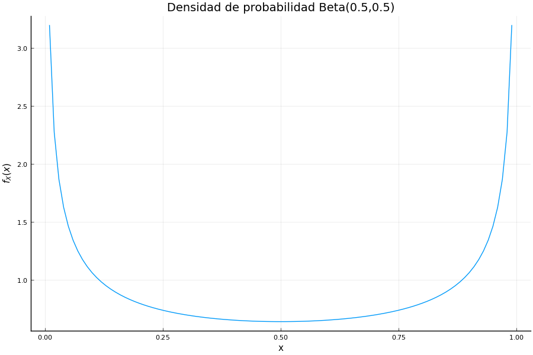

```julia
plot(p)
```

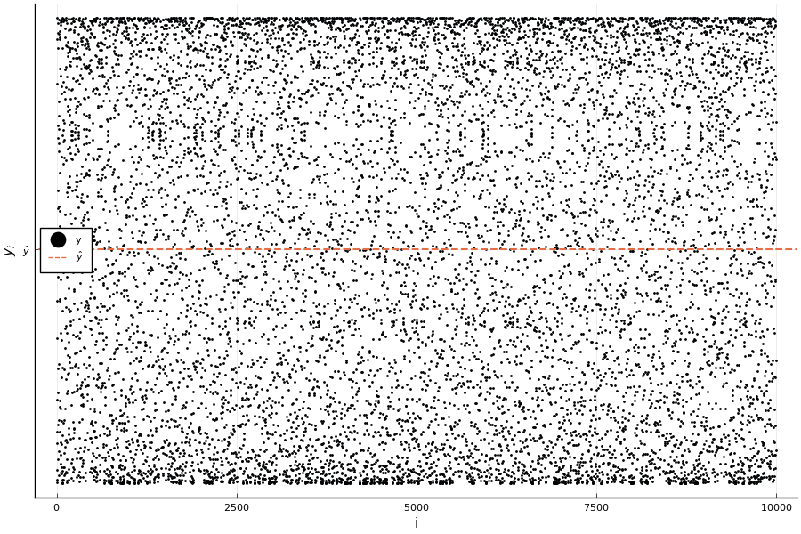

```julia
plot(p)
```

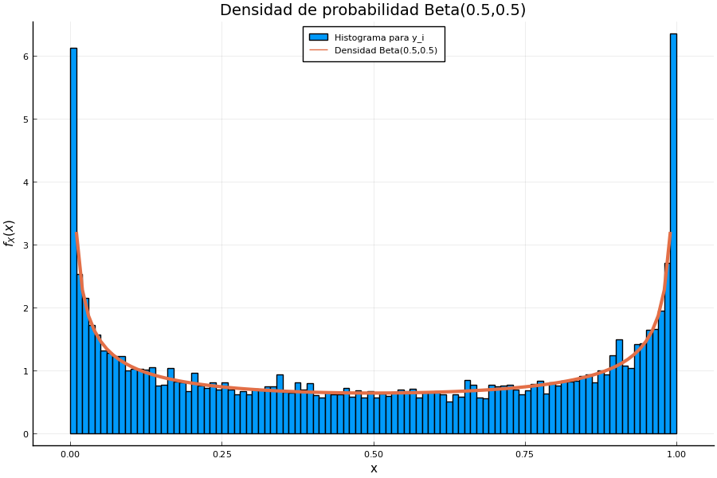

```julia
plot(p)
```

### Teorema ergódico

#### Formulación probabilista de Birkhoff-Khinchin

Sea $h \, : \, E \to E $ y $f^k(x)$ la función dada por $k$ evaluaciones de $f$ sobre $x$. Si $f$ tiene distribución invariante $\pi$ y es ergódica (condición de regularidad) entonces $\forall x_0 \in E$ \begin{align*} \lim_{n\to \infty}\frac{1}{n}\sum_{k=1}^n h(f^k(x_0)) = \mathbb{E}\left[ h(X) \right] \end{align*} donde $X\sim \mathcal{L}(\pi)$ (X tiene distribución de probabilidad dada por $\pi$).

Decimos que una función $f$ es ergódica si para una "amplia" familia de conjuntos $A\subset E$ se tiene que $$f^{-1}(A) \subset A \, \implies \, \int_A \pi(x)\mathrm{d}x \in \left\{0,1 \right\}$$.

#### Ejemplo de no ergodicidad

Supongamos que tenemos dos monedas, una es justa y la otra tiene dos caras. Si elegimos al azar, con las mismas probabilidades una moneda, y procedemos a hacer lanzamientos de esta denotando $Y_n = 1$ obtener "cara" y $Y_n=0$ obtener "cruz" en el $n-$ésimo lanzamiento tenemos que $\mathbb{E}[Y_n]=0.5(0.5+1)=3/4$ pero el promedio de la trayectoria es 1/2 ó 1 dependiendo de la moneda que se elija al principio.

#### Ejemplo de ergodicidad

El mapeo logístico es ergódico.

```julia
mean(Beta(0.5,0.5))
```

```
0.5
```

```julia
mean(x)
```

```
0.5016912926704211
```

```julia
var(Beta(0.5,0.5))
```

```
0.125
```

```julia
var(x)
```

```
0.12456771513400763
```

```julia
std(Beta(0.5,0.5))
```

```
0.3535533905932738
```

```julia
std(x)
```

```
0.35294151800830637
```

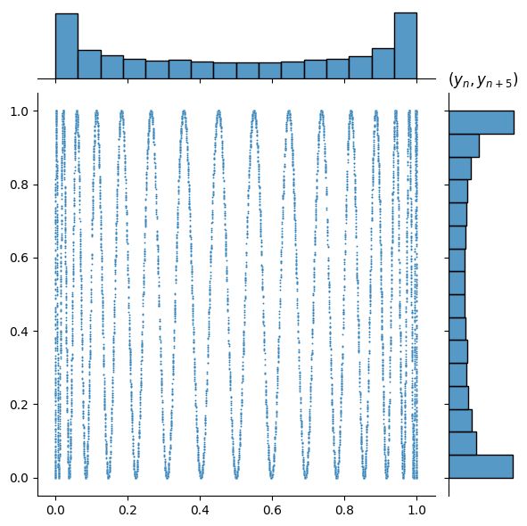

```
PyObject Text(0.5, 1.0, '$(y_n,y_{n+5})$')
```

```julia
Seaborn.jointplot( x[1:(n-m)], [ x[i+m] for i in 1:(n-m) ], s=2 );Seaborn.xlabel("\$y_n\$");Seaborn.ylabel("\$y_{n+$(m)}\$");Seaborn.title("\$(y_n,y_{n+$(m)})\$")
```

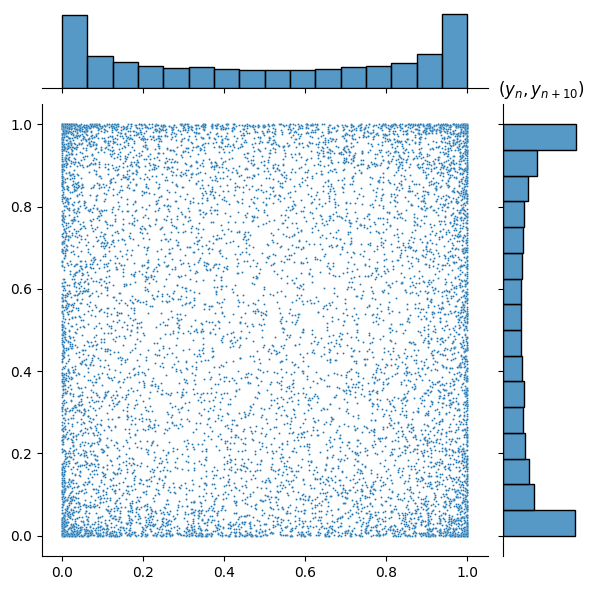

```
PyObject Text(0.5, 1.0, '$(y_n,y_{n+10})$')
```

```julia
m=10;p=Seaborn.jointplot( x[1:(n-m)], [ x[i+m] for i in 1:(n-m) ], s=2 );Seaborn.xlabel("\$y_n\$");Seaborn.ylabel("\$y_{n+$(m)}\$");Seaborn.title("\$(y_n,y_{n+$(m)})\$")
```

### Proposición

Si $X\sim \text{Beta}(0.5,0.5) \, \implies \frac{2}{\pi}\arcsin \left( \sqrt{X} \right)\sim \text{Uniforme}(0,1)$

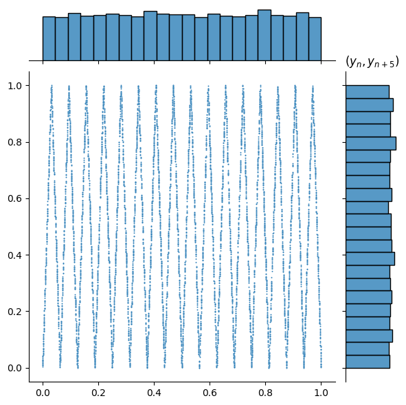

```
PyObject Text(0.5, 1.0, '$(y_n,y_{n+5})$')
```

```julia
Seaborn.jointplot( F_arcsin.(y[1:(n-m)]), F_arcsin.([ y[i+m] for i in 1:(n-m) ]), s=2 );Seaborn.xlabel("\$y_n\$");Seaborn.ylabel("\$y_{n+$(m)}\$");Seaborn.title("\$(y_n,y_{n+$(m)})\$")
```

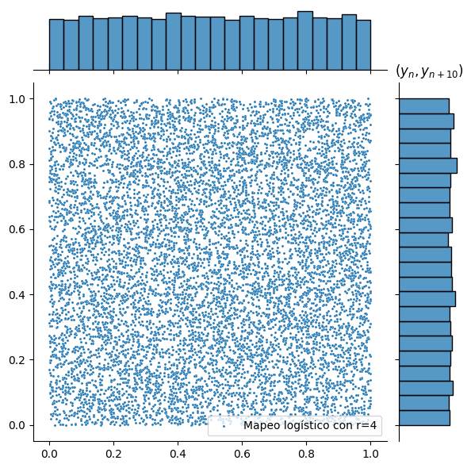

```
PyObject Text(0.5, 1.0, '$(y_n,y_{n+10})$')
```

```julia
# Segunda simulacion con mapeo logistico
m=10;Seaborn.jointplot( F_arcsin.(y[1:(n-m)]), F_arcsin.([ y[i+m] for i in 1:(n-m) ]), s=5, label="Mapeo logístico con r=4");Seaborn.xlabel("\$y_n\$");Seaborn.ylabel("\$y_{n+$(m)}\$");Seaborn.title("\$(y_n,y_{n+$(m)})\$")
```

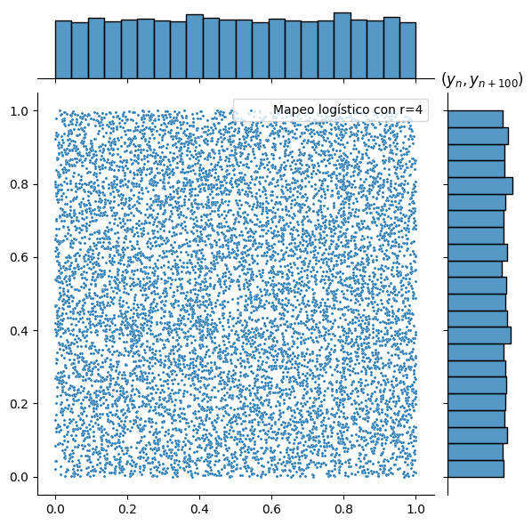

```
PyObject Text(0.5, 1.0, '$(y_n,y_{n+100})$')
```

```julia
# Segunda simulacion con mapeo logistico
m=100;Seaborn.jointplot( F_arcsin.(y[1:(n-m)]), F_arcsin.([ y[i+m] for i in 1:(n-m) ]), s=5, label="Mapeo logístico con r=4" );Seaborn.xlabel("\$y_n\$");Seaborn.ylabel("\$y_{n+$(m)}\$");Seaborn.title("\$(y_n,y_{n+$(m)})\$")
```

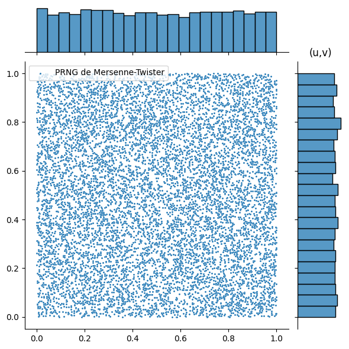

```
PyObject Text(0.5, 1.0, '(u,v)')
```

```julia
m=100;Seaborn.jointplot( rand(n-m), rand(n-m), s=5, label="PRNG de Mersenne-Twister" );Seaborn.title("(u,v)")
```

## Generador lineal congruencial

\begin{equation*} x_{n+1}=f_{glc}(x_n)= a(x_n + c ) \text{ mod } m \\ y_n = g_{glc}(x_n)= \frac{x_n}{m} \end{equation*}

En 1988 Park y Miller sugierieron la elección de parámetros $m=2^{31}-1$, $a=7^5$, $c=0$.

```julia
M = 2^31 - 1
```

```
2147483647
```

```julia
A = 7^5
```

```
16807
```

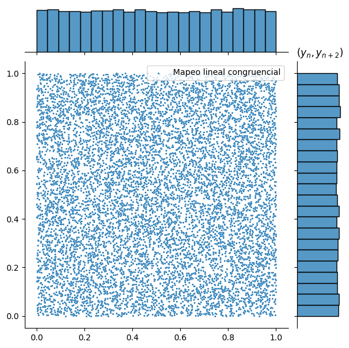

```
PyObject Text(0.5, 1.0, '$(y_n,y_{n+2})$')
```

```julia
m=2;Seaborn.jointplot( y[1:(n-m)], [ y[i+m] for i in 1:(n-m)], s=5, label="Mapeo lineal congruencial" );Seaborn.xlabel("\$y_n\$");Seaborn.ylabel("\$y_{n+$(m)}\$");Seaborn.title("\$(y_n,y_{n+$(m)})\$")
```

Veamos qué sucede si en cambio consideramos $m=2^7-1$, $a=7^2$ y $c=0$.

```julia
M = 2^7-1
```

```
127
```

```julia
A = 7^2
```

```
49
```

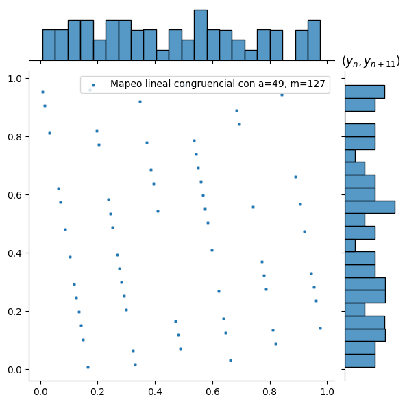

```
PyObject Text(0.5, 1.0, '$(y_n,y_{n+11})$')
```

```julia
m=11
Seaborn.jointplot( y[1:(n-m)], [ y[i+m] for i in 1:(n-m)], s=10, label="Mapeo lineal congruencial con a=$(A), m=$(M)" )
Seaborn.xlabel("\$y_n\$")
Seaborn.ylabel("\$y_{n+$(m)}\$")
Seaborn.title("\$(y_n,y_{n+$(m)})\$")
```

## Generador retrasado de Fibonacci

\begin{align*} x_n = f_{fib}(x_{n-1},x_{n-2}) = x_{n-1} \star x_{n-2} \text{ mod } m \end{align*}

con $\star$ una operación binaria para la cual usualmente se elige adición, multiplicación o el xor bit a bit.

Más en general para $0<j<k$ se considera \begin{align*} x_n = f_{fib}(x_{n-j},x_{n-k}) \end{align*}

```julia
1 ⊻ 1
```

```
0
```

```julia
1 ⊻ 0
```

```
1
```

```julia
0 ⊻ 1
```

```
1
```

```julia
0 ⊻ 0
```

```
0
```

```julia
parse(Int, "1110"; base=2)
```

```
14
```

```julia
parse(Int, "1001"; base=2)
```

```
9
```

```julia
14 ⊻ 9
```

```
7
```

```julia
digits(7,base=2,pad=4)
```

```
4-element Array{Int64,1}:
 1
 1
 1
 0
```

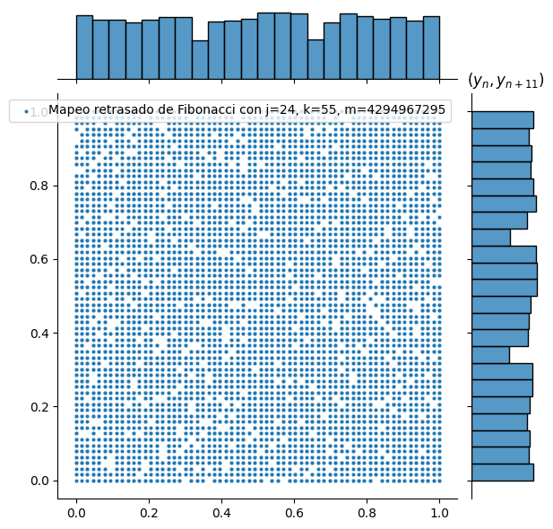

```
PyObject Text(0.5, 1.0, '$(y_n,y_{n+11})$')
```

```julia
m=11
Seaborn.jointplot( y[1:(n-m)], [ y[i+m] for i in 1:(n-m)], s=10, label="Mapeo retrasado de Fibonacci con j=$(j), k=$(k), m=$(M)" )
Seaborn.xlabel("\$y_n\$")
Seaborn.ylabel("\$y_{n+$(m)}\$")
Seaborn.title("\$(y_n,y_{n+$(m)})\$")
```